# Relações - subqueries

[output not shown]

# 1 Subqueries - idéia

Considere o exemplo de das duas tabelas abaixo, com dados de **Livros** e **Notas** dadas a esses livros:

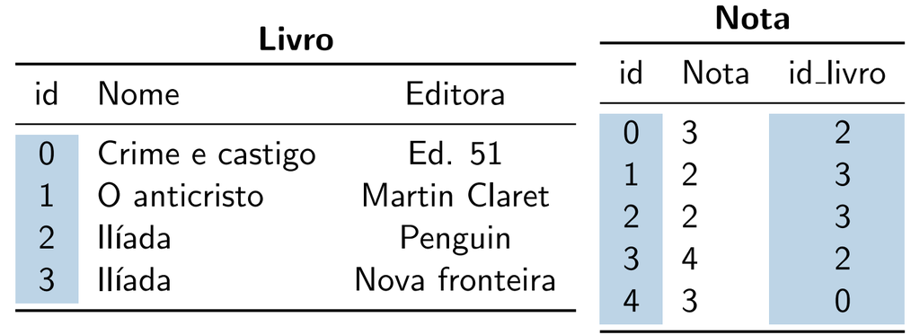

Suponha que queremos buscar todas as notas na tabela **Nota** que foram dadas ao livro Crime e castigo. Como poderíamos proceder?

Para buscar as notas dos livros na tabela Nota, primeiro precisamos descobrir qual é o id do livro Crime e castigo. Dessa forma, podemos resolver o problema usando duas queries: uma para buscar o id do livro na tabela **Livro**, e em seguida, com esse id, buscar as sua notas na tabela **Nota.**

1. Buscando o id:

```sql
SELECT "id" FROM "Livro"
WHERE "id" = "Crime e castigo";
```

Essa busca retorna o id 0.

2. Buscando as notas:

```sql
SELECT 'Nota' FROM 'Nota'
WHERE "id_livro" = 0;
```

O que retorna as notas do livro Crime e castigo.

No entanto, essa forma não é muit interessante, pois precisamos salvar o indice 0 em algum lugar, para depois usá-lo na busca pelas notas. A linguagem SQL nos permite resolver esse problema por meio de **subqueries**, ou **queries aninhadas**. No lugar de alocar o id 0 na segunda query, criamos uma nova query para buscar esse valor (que é a primeira que fizemos), ou seja, juntamos ambas as queries em uma única:

```sql
SELECT 'Nota' FROM 'Nota'
WHERE "id_livro" = (
    SELECT "id" FROM "Livro"
    WHERE "id" = "Crime e castigo";
    );
```

Essa é uma query aninhada, e o ordem de execução dos comandos segue a ordem dos parênteses: as queries com parênteses mais internos são resolvidas primeiro, no caso acima, primeiro a *query* da busca de id, e em seguida a *query* de busca por notas.

# 2 Subqueries - aplicações

Nesta sequência usaremos o banco de dados `longlist-2.db`. Ainda é um banco de dados de livros, porém com mais tabelas. Os nomes das tabelas (para ver no terminal basta usar o comando `.tables`), e das colunas (atributos) de cada uma são mostrados abaixo:

- `authors`:
  1. id
  2. name
  3. country
  4. birth
- `authored`:
  1. author_id
  2. book_id
- `books`:
  1. id
  2. isbn
  3. title
  4. publisher_id
  5. format
  6. pages
  7. published
  8. year
- `ratings`:
  1. book_id
  2. rating
- `translators`:
  1. id
  2. name
- `translated`:
  1. translator_id
  2. book_id
- `publisher`:
  1. id
  2. publisher

## 2.1 Exemplo 1

Vamos criar uma query para buscar todos os livros que foram publicados pela editora “Fitzcarraldo Editions”. Sabemos que os livros estão na tabela `books` (coluna `title`). Porém a tabela não contém o nome das editoras, simplesmente o seu id (`publisher_id`), de forma que primeiro é necessário encontrar o id do editor “Fitzcarraldo Editions”. Vamos construir as suas queries de forma separada, e em seguida aninhá-las:

1. Descobrindo o id de “Fitzcarraldo Editions”

```sql
SELECT "id" FROM "publishers" WHERE "publisher" = 'Fitzcarraldo Editions';
```

|  | id |
| --- | --- |
| 1 | 5 |

2. Agora usamos este id para descobrir os livros publicados:

```sql
SELECT * FROM "books" WHERE "publisher_id" = 5;
```

|  | id | isbn | title | publisher_id | format | pages | published | year |
| --- | --- | --- | --- | --- | --- | --- | --- | --- |
| 1 | 9 | 9781804270288 | While We Were Dreaming | 5 | paperback | 528 | 2023-03-30 | 2023 |
| 2 | 11 | 9781913097660 | Still Born | 5 | paperback | 200 | 2022-06-22 | 2023 |
| 3 | 14 | 9781913097875 | Paradais | 5 | paperback | 118 | 2022-03-23 | 2022 |
| 4 | 22 | 9781913097721 | A New Name: Septology VI-VII | 5 | paperback | 228 | 2021-09-08 | 2022 |
| 5 | 25 | 9781910695593 | The Books of Jacob | 5 | paperback | 920 | 2021-11-15 | 2022 |
| 6 | 33 | 9781913097530 | In Memory of Memory | 5 | paperback | 510 | 2021-02-17 | 2021 |
| 7 | 34 | 9781913097172 | Minor Detail | 5 | paperback | 144 | 2020-05-06 | 2021 |
| 8 | 45 | 9781910695913 | The Other Name: Septology I-II | 5 | paperback | 351 | 2019-10-10 | 2020 |
| 9 | 48 | 9781913097097 | Hurricane Season | 5 | paperback | 229 | 2020-02-19 | 2020 |
| 10 | 55 | 9781910695715 | Drive Your Plow Over the Bones of the Dead | 5 | paperback | 270 | 2019-01-01 | 2019 |

[output cut: 2 more lines]

Vamos realizar a mesma busca, porém usando uma query aninhada (subqueries):

```sql
SELECT * FROM "books"
WHERE "publisher_id" = (
  SELECT "id" FROM "publishers" WHERE "publisher" = 'Fitzcarraldo Editions'
);
```

|  | id | isbn | title | publisher_id | format | pages | published | year |
| --- | --- | --- | --- | --- | --- | --- | --- | --- |
| 1 | 9 | 9781804270288 | While We Were Dreaming | 5 | paperback | 528 | 2023-03-30 | 2023 |
| 2 | 11 | 9781913097660 | Still Born | 5 | paperback | 200 | 2022-06-22 | 2023 |
| 3 | 14 | 9781913097875 | Paradais | 5 | paperback | 118 | 2022-03-23 | 2022 |
| 4 | 22 | 9781913097721 | A New Name: Septology VI-VII | 5 | paperback | 228 | 2021-09-08 | 2022 |
| 5 | 25 | 9781910695593 | The Books of Jacob | 5 | paperback | 920 | 2021-11-15 | 2022 |
| 6 | 33 | 9781913097530 | In Memory of Memory | 5 | paperback | 510 | 2021-02-17 | 2021 |
| 7 | 34 | 9781913097172 | Minor Detail | 5 | paperback | 144 | 2020-05-06 | 2021 |
| 8 | 45 | 9781910695913 | The Other Name: Septology I-II | 5 | paperback | 351 | 2019-10-10 | 2020 |
| 9 | 48 | 9781913097097 | Hurricane Season | 5 | paperback | 229 | 2020-02-19 | 2020 |
| 10 | 55 | 9781910695715 | Drive Your Plow Over the Bones of the Dead | 5 | paperback | 270 | 2019-01-01 | 2019 |

[output cut: 2 more lines]

EXERCICIO: Faça a busca de todos os livros publicados pela editora MacLehose Press (sem usar query aninhada e usando).

## 2.2 Exemplo 2

Vamos encontrar todas as notas `ratings` do livro chamado “In Memory of Memory”.

Primeiro vamos encontrar o id do livro:

```sql
SELECT "id" FROM "books" WHERE "title" = 'In Memory of Memory';
```

|  | id |
| --- | --- |
| 1 | 33 |

Agora com esse id podemos fazer a busca na tabela de `ratings` pelas notas:

```sql
SELECT "rating" FROM "ratings" WHERE "book_id" = 33;
```

|  | rating |
| --- | --- |
| 1 | 3 |
| 2 | 4 |
| 3 | 4 |
| 4 | 4 |
| 5 | 3 |
| 6 | 4 |
| 7 | 3 |
| 8 | 4 |
| 9 | 4 |
| 10 | 3 |

[output cut: 1544 more lines]

Vamos montar uma *query* mais dinâmica, combinando as duas anteriores:

```sql
SELECT "rating" FROM "ratings"
WHERE "book_id" = (
    SELECT "id" FROM "books"
    WHERE "title" = 'In Memory of Memory'
);
```

|  | rating |
| --- | --- |
| 1 | 3 |
| 2 | 4 |
| 3 | 4 |
| 4 | 4 |
| 5 | 3 |
| 6 | 4 |
| 7 | 3 |
| 8 | 4 |
| 9 | 4 |
| 10 | 3 |

[output cut: 1544 more lines]

Vamos calcular a **nota média** deste livro:

```sql
SELECT AVG("rating") AS "Media" FROM "ratings"
WHERE "book_id" = (
    SELECT "id" FROM "books"
    WHERE "title" = 'In Memory of Memory'
) AS 'MEDIA';
```

|  | Media |
| --- | --- |
| 1 | 3.86036036036036 |

## 2.3 Exemplo 3

Agora vamos descobrir o nome do autor que escreveu o livro “Flights”. Quais informações precisamos para essa query?

1. O id do livro cujo nome é Flights (presente na tabela `books`).
2. Com o id do livro, o id do autor que escreveu o livro cujo nome é Flights (presente na tabela `authored`).
3. Com o id do autor, na tabela `author` buscamos o nome do mesmo.

Neste exemplo temos então que responder a 3 perguntas, de forma que a query terá 3 níveis. Vamos responder cada pergunta individualmente e em seguida criar a query composta.

1. Id do livro:

```sql
SELECT "id" FROM "books" WHERE "title" = 'Flights';
```

|  | id |
| --- | --- |
| 1 | 78 |

2. Id do autor, sabendo o id do livro (78):

```sql
SELECT "author_id" FROM "authored" WHERE "book_id" = 78;
```

|  | author_id |
| --- | --- |
| 1 | 58 |

2. Nome do autor, sabendo o id do autor (58)

```sql
SELECT "name" FROM "authors" WHERE "id" = 58;
```

|  | name |
| --- | --- |
| 1 | Olga Tokarczuk |

Agora podemos montar uma query aninhada com todas as autras:

```sql
SELECT "name" FROM "authors"
WHERE "id" = (
        SELECT "author_id" FROM
        "authored" WHERE "book_id" = (
            SELECT "id" FROM "books"
            WHERE "title" = 'Flights'
    )
);
```

|  | name |
| --- | --- |
| 1 | Olga Tokarczuk |

EXERCICIO: Encontre o autor do livro “The Birthday Party”.

# 3 IN

Usamos o comando IN para selecionar elementos que estejam dentro de um conjunto. Até agora usamos o “=”, ou seja, fizemos buscas em que algo deveria ser igual a um único valor. Agora podemos buscar elementos que sejam iguais a **qualquer elemento** de um conjunto. Por exemplo, se quisermos selecionar o nome do livro cujo id é 1, fazemos:

```sql
SELECT "title" FROM "books" WHERE "id" = 1;
```

|  | title |
| --- | --- |
| 1 | Boulder |

E se quisessemos selecionar os nomes de livros com ids = 1 e 2? Neste caso podemos substituir o “=” pelo IN:

```sql
SELECT "title" FROM "books" WHERE "id" IN (1,2);
```

|  | title |
| --- | --- |
| 1 | Boulder |
| 2 | Whale |

## 3.1 Exemplo 1

Vamos buscar todos os livros que foram escritos pela autora “Fernanda Melchor”. Para isso precisamos das seguintes informações:

1. O id da autora (na tabela `authors`)
2. Com o id da autora, os ids dos livros que ela escreveu (da tabela `authored`) -> aqui temos um conjunto de elementos
3. Todos os nomes de livros que estejam no conjuntos desses ids.

Respondendo às 3 perguntas:

1. id da autora:

```sql
SELECT "id" FROM "authors" WHERE "name" = 'Fernanda Melchor';
```

|  | id |
| --- | --- |
| 1 | 24 |

2. Ids dos livros da autora:

```sql
SELECT "book_id" FROM "authored" WHERE "author_id" = 24;
```

|  | book_id |
| --- | --- |
| 1 | 14 |
| 2 | 48 |

3. Nome dos livros cujos ids estão no conjunto acima:

```sql
SELECT "title" FROM "books" WHERE "id" IN (14,48);
```

|  | title |
| --- | --- |
| 1 | Paradais |
| 2 | Hurricane Season |

Agora podemos aninhar todas as queries:

```sql
SELECT "title" FROM "books" WHERE "id" IN (
    SELECT "book_id" FROM "authored" WHERE "author_id" = (
        SELECT "id" FROM "authors" WHERE "name" = 'Fernanda Melchor'
    )
);
```

|  | title |
| --- | --- |
| 1 | Paradais |
| 2 | Hurricane Season |

# 4 JOIN

(PARA UMA EXPLICAÇÃO COMPLETA VER A APRESENTAÇÃO EM PDF)

Usamos o comando JOIN para unir informações de duas tabelas distintas. Existem básicamente 4 tipos diferentes de JOIN, como mostrado na Figura abaixo:

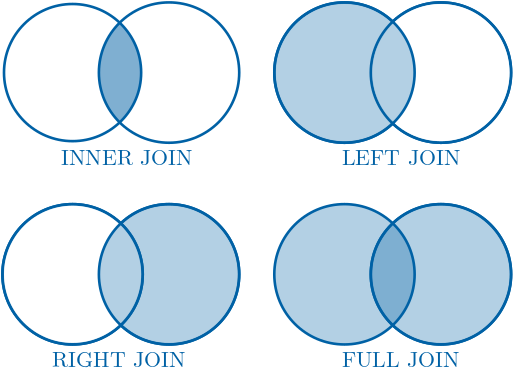

Considerando o banco de dados de migração de leões marinhos `sea_lions.db`. Para realizarmos um JOIN precisamos selecionar as duas tabelas que serão juntadas, bem como os atributos de cada uma que serão comparados (valores iguais serão colocados um ao lado do outro).

## 4.1 INNER JOIN

Para realizarmos o INNER JOIN entre as tabelas `sea_lions` e `migrations`, usando os ids de cada uma, temos:

```sql
SELECT * FROM "sea_lions"
JOIN "migrations"
ON "migrations"."id" = "sea_lions"."id";
```

|  | id | name | species | id | distance | days |
| --- | --- | --- | --- | --- | --- | --- |
| 1 | 10484 | Ayah | Zalophus californianus | 10484 | 1000 | 107 |
| 2 | 11728 | Spot | Zalophus californianus | 11728 | 1531 | 56 |
| 3 | 11729 | Tiger | Zalophus californianus | 11729 | 1370 | 37 |
| 4 | 11732 | Mabel | Zalophus californianus | 11732 | 1622 | 62 |
| 5 | 11734 | Rick | Zalophus californianus | 11734 | 1491 | 58 |

## 4.2 LEFT JOIN

```sql
SELECT * FROM "sea_lions"
LEFT JOIN "migrations"
ON "migrations"."id" = "sea_lions"."id";
```

|  | id | name | species | id | distance | days |
| --- | --- | --- | --- | --- | --- | --- |
| 1 | 10484 | Ayah | Zalophus californianus | 10484 | 1000 | 107 |
| 2 | 11728 | Spot | Zalophus californianus | 11728 | 1531 | 56 |
| 3 | 11729 | Tiger | Zalophus californianus | 11729 | 1370 | 37 |
| 4 | 11732 | Mabel | Zalophus californianus | 11732 | 1622 | 62 |
| 5 | 11734 | Rick | Zalophus californianus | 11734 | 1491 | 58 |
| 6 | 11790 | Jolee | Zalophus californianus |  |  |  |

## 4.3 RIGHT JOIN

```sql
SELECT * FROM "sea_lions"
RIGHT JOIN "migrations"
ON "migrations"."id" = "sea_lions"."id";
```

|  | id | name | species | id | distance | days |
| --- | --- | --- | --- | --- | --- | --- |
| 1 | 10484 | Ayah | Zalophus californianus | 10484 | 1000 | 107 |
| 2 | 11728 | Spot | Zalophus californianus | 11728 | 1531 | 56 |
| 3 | 11729 | Tiger | Zalophus californianus | 11729 | 1370 | 37 |
| 4 | 11732 | Mabel | Zalophus californianus | 11732 | 1622 | 62 |
| 5 | 11734 | Rick | Zalophus californianus | 11734 | 1491 | 58 |
| 6 |  |  |  | 11735 | 2723 | 82 |
| 7 |  |  |  | 11736 | 1571 | 52 |
| 8 |  |  |  | 11737 | 1957 | 92 |

## 4.4 FULL JOIN

```sql
SELECT * FROM "sea_lions"
FULL JOIN "migrations"
ON "migrations"."id" = "sea_lions"."id";
```

|  | id | name | species | id | distance | days |
| --- | --- | --- | --- | --- | --- | --- |
| 1 | 10484 | Ayah | Zalophus californianus | 10484 | 1000 | 107 |
| 2 | 11728 | Spot | Zalophus californianus | 11728 | 1531 | 56 |
| 3 | 11729 | Tiger | Zalophus californianus | 11729 | 1370 | 37 |
| 4 | 11732 | Mabel | Zalophus californianus | 11732 | 1622 | 62 |
| 5 | 11734 | Rick | Zalophus californianus | 11734 | 1491 | 58 |
| 6 | 11790 | Jolee | Zalophus californianus |  |  |  |
| 7 |  |  |  | 11735 | 2723 | 82 |
| 8 |  |  |  | 11736 | 1571 | 52 |
| 9 |  |  |  | 11737 | 1957 | 92 |

## 4.5 NATURAL JOIN

O NATURAL JOIN pode ser pensado em uma simplificação do INNER JOIN, quando as colunas que serão comparadas de ambas as tabelas possuem o mesmo nome. No caso anterior, ambas as tabelas possuem uma coluna chamada “id”, podemos então usar o NATURAL JOIN sem especificar as colunas, e automáticamente elas serão juntadas:

```sql
SELECT * FROM "sea_lions"
NATURAL JOIN "migrations";
```

|  | id | name | species | distance | days |
| --- | --- | --- | --- | --- | --- |
| 1 | 10484 | Ayah | Zalophus californianus | 1000 | 107 |
| 2 | 11728 | Spot | Zalophus californianus | 1531 | 56 |
| 3 | 11729 | Tiger | Zalophus californianus | 1370 | 37 |
| 4 | 11732 | Mabel | Zalophus californianus | 1622 | 62 |
| 5 | 11734 | Rick | Zalophus californianus | 1491 | 58 |

## 4.6 MULTIPLOS JOIN

Podemos usar o JOIN pra juntar mais de duas tabelas ao mesmo tempo. Considere as 3 tabelas abaixo, em que queremos realizar o JOIN por:

1. Elemento A da tabela1
2. Elemento E da tabela2
3. Elemento I da tabela3

E queremos mostrar os seguintes termos:

1. Elemento D da tabela1
2. Elemento G da tabela2
3. Elemento J da tabela3

E ainda queremos aplicar algumas condições nas tabelas. A sintaxe fica então:

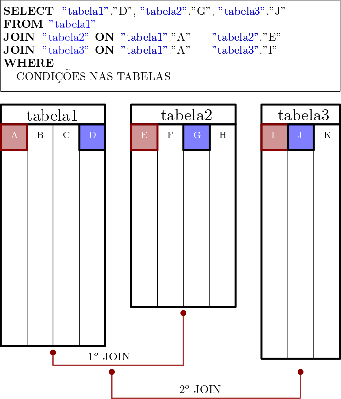

Note que no SELECT temos acesso a todos os elementos das tabelas, basta colocarmos o nome das tabelas antes. Ainda, primeiro fazemos **todos** os JOINs, para em seguida aplicar as condições WHERE. Note também que a sequência em que os JOINS são escritos importa, a primeiro JOIN junta as tabelas 1 e 2, e o resultado deste JOIN é juntado na tabela 3.

## 4.7 JOIN COM MULTIPLAS CONDIÇÕES

Um outro caso possível é realizar JOINS em que existem multiplas condições de junções, por exemplo:

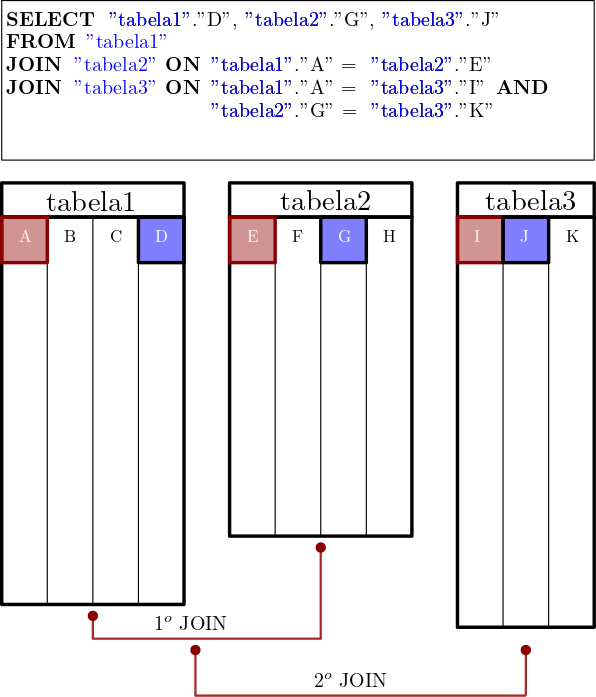

Neste caso, a tabela3 se junta às outras por 2 elementoe, combinados por um “AND”.

# 5 SETS

Um resumo das operações entre conjuntos (SETS) é apresentado abaixo:

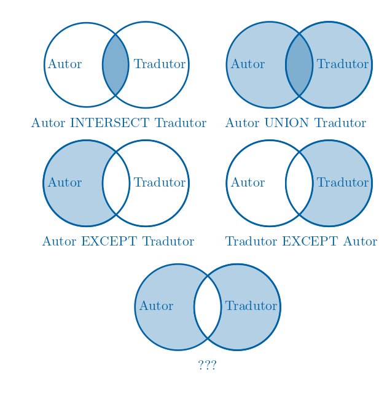

## 5.1 UNION

Vamos encontrar todos os nomes de autores (da tabela `authors`) e todos os tradutores (da tabela `translators`):

```sql
SELECT "name" FROM "authors";
```

|  | name |
| --- | --- |
| 1 | Adania Shibli |
| 2 | Ahmed Saadawi |
| 3 | Alia Trabucco Zerán |
| 4 | Amanda Svensson |
| 5 | Andrey Kurkov |
| 6 | Andrzej Tichy |
| 7 | Annie Ernaux |
| 8 | Antonio Muñoz Molina |
| 9 | Ariana Harwicz |
| 10 | Benajamín Labatut |

[output cut: 62 more lines]

```sql
SELECT "name" FROM "translators"
```

|  | name |
| --- | --- |
| 1 | Adrian Nathan West |
| 2 | Alison L. Strayer |
| 3 | Angela Rodel |
| 4 | Aniruddhan Vasudevan |
| 5 | Anna Moschovakis |
| 6 | Anne McLean |
| 7 | Annelise Finegan Wasmoen |
| 8 | Anton Hur |
| 9 | Antonia Lloyd-Jones |
| 10 | Camilo A. Ramirez |

[output cut: 64 more lines]

Agora podemos selecionar a **união**, ou seja, todos que são autores ou tradutores:

```sql
SELECT "name" FROM "authors"
UNION
SELECT "name" FROM "translators";
```

|  | name |
| --- | --- |
| 1 | Adania Shibli |
| 2 | Adrian Nathan West |
| 3 | Ahmed Saadawi |
| 4 | Alia Trabucco Zerán |
| 5 | Alison L. Strayer |
| 6 | Amanda Svensson |
| 7 | Andrey Kurkov |
| 8 | Andrzej Tichy |
| 9 | Angela Rodel |
| 10 | Aniruddhan Vasudevan |

[output cut: 135 more lines]

OBS Observe a cardinalidade dos conjuntos:

1. Autores: 72
2. Tradutores: 74
3. Autores UNION Tradutores: 145

Ou seja, como Autores + Tradutores - 1 = Autores UNION Tradutores, temos que um nome é tanto autor como tradutor.

## 5.2 INTERSECT

Podemos descobrir qual é usando o INTERESECT:

```sql
SELECT "name" FROM "authors"
INTERSECT
SELECT "name" FROM "translators";
```

|  | name |
| --- | --- |
| 1 | Ngũgĩ wa Thiong'o |

## 5.3 EXCEPT

Agora podemos usar o EXCEPT para selecinar **somente** os autores e **somente** os tradutores.

```sql
SELECT "name" FROM "authors"
EXCEPT
SELECT "name" FROM "translators";
```

|  | name |
| --- | --- |
| 1 | Adania Shibli |
| 2 | Ahmed Saadawi |
| 3 | Alia Trabucco Zerán |
| 4 | Amanda Svensson |
| 5 | Andrey Kurkov |
| 6 | Andrzej Tichy |
| 7 | Annie Ernaux |
| 8 | Antonio Muñoz Molina |
| 9 | Ariana Harwicz |
| 10 | Benajamín Labatut |

[output cut: 61 more lines]

Agora somente os tradutores:

```sql
SELECT "name" FROM "translators"
EXCEPT
SELECT "name" FROM "authors";
```

|  | name |
| --- | --- |
| 1 | Adrian Nathan West |
| 2 | Alison L. Strayer |
| 3 | Angela Rodel |
| 4 | Aniruddhan Vasudevan |
| 5 | Anna Moschovakis |
| 6 | Anne McLean |
| 7 | Annelise Finegan Wasmoen |
| 8 | Anton Hur |
| 9 | Antonia Lloyd-Jones |
| 10 | Camilo A. Ramirez |

[output cut: 63 more lines]

## 5.4 Exemplo 1

Vamos usar as operações entre conjuntos para descobrir quais livros foram traduzidos de forma conjunta pela tradutora “Sophie Hughes” e pela tradutora “Margaret Jull Costa”. Para isso, vamos usar as tabelas `translated` e `translator`. Primeiro podemos buscar todos os ids dos livros que foram traduzidos por “Sophie Hughes”, usando uma query aninhada (descobrindo o id da tradutora buscamos os livros traduzidos com com o id desse tradutor):

```sql
SELECT "book_id" FROM "translated" WHERE "translator_id" = (
    SELECT "id" FROM "translators"
    WHERE "name" = 'Sophie Hughes');
```

|  | book_id |
| --- | --- |
| 1 | 14 |
| 2 | 48 |
| 3 | 50 |
| 4 | 63 |

Agora podemos encontrar todos os livros que foram traduzidos por “Margaret Jull Costa”

```sql
SELECT "book_id" FROM "translated" WHERE "translator_id" = (
    SELECT "id" FROM "translators"
    WHERE "name" = 'Margaret Jull Costa');
```

|  | book_id |
| --- | --- |
| 1 | 50 |

Finalmente, para encontrar os livros em que ambas foram traduzidas, usamos o INTERSECT com as duas *queries* anteriores:

```sql
SELECT "book_id" FROM "translated" WHERE "translator_id" = (
    SELECT "id" FROM "translators"
    WHERE "name" = 'Sophie Hughes')
INTERSECT
SELECT "book_id" FROM "translated" WHERE "translator_id" = (
    SELECT "id" FROM "translators"
    WHERE "name" = 'Margaret Jull Costa');
```

|  | book_id |
| --- | --- |
| 1 | 50 |

DESAFIO: Crie a *query* para encontrar o nome do livro que as duas traduziram juntas.

# 6 GROUP BY

| book_id | rating |
| --- | --- |
| 1 | 4 |
| 1 | 4 |
| 2 | 8 |
| 3 | 7 |
| 3 | 4 |
| 4 | 7 |

Se aplicarmos a função AVG(“rating”) obteremos a média de todos os livros, no entanto, podemos estar interessados em obter a média **por livro**, algo como:

| book_id | mean(rating) |
| --- | --- |
| 1 | 4.0 |
| 2 | 8.0 |
| 3 | 5.5 |
| 4 | 7.0 |

Para isso usamos o GROUP BY. Vamos fazer esse mesmo exemplo com as notas no BD:

```sql
SELECT "book_id",AVG("rating") AS "average rating"
FROM "ratings"
GROUP BY "book_id";
```

|  | book_id | average rating |
| --- | --- | --- |
| 1 | 1 | 3.774019431450162 |
| 2 | 2 | 3.971428571428572 |
| 3 | 3 | 3.043859649122807 |
| 4 | 4 | 3.568322981366459 |
| 5 | 5 | 4.05919796308084 |
| 6 | 6 | 3.762525458248473 |
| 7 | 7 | 3.640718562874251 |
| 8 | 8 | 3.824196597353497 |
| 9 | 9 | 3.998581560283688 |
| 10 | 10 | 4.040706605222734 |

[output cut: 68 more lines]

Agora vamos aplicar um filtro nas notas médias, para buscar somente aquelas que são > 4.0. Poderíamos pensar na seguinte *query*:

```sql
SELECT "book_id",AVG("rating") AS "average rating"
FROM "ratings"
GROUP BY "book_id"
WHERE "average rating" > 4;
```

```sql
SELECT "book_id",ROUND(AVG("rating"),2) AS "average rating"
FROM "ratings"
GROUP BY "book_id"
HAVING "average rating" > 4;
```

|  | book_id | average rating |
| --- | --- | --- |
| 1 | 5 | 4.06 |
| 2 | 10 | 4.04 |
| 3 | 11 | 4.14 |
| 4 | 18 | 4.09 |
| 5 | 20 | 4.04 |
| 6 | 22 | 4.5 |
| 7 | 25 | 4.05 |
| 8 | 28 | 4.14 |
| 9 | 42 | 4.51 |
| 10 | 45 | 4.19 |

[output cut: 3 more lines]

DESAFIOS:

1. Encontre o número de votos que cada livro obteve, e ordene o resultado de forma decrescente

**SOLUÇÃO**

```sql
SELECT "book_id",COUNT("rating") AS "count"
FROM "ratings"
GROUP BY "book_id"
ORDER BY "count" DESC;
```

2. Imprima o resultado passado com o nome de cada livro

**SOLUÇÃO**

```sql
SELECT "title" FROM "books" WHERE "id" IN (
    SELECT "book_id" FROM (
        SELECT "book_id",COUNT("book_id")
        FROM "ratings"
        GROUP BY "book_id"
        ORDER BY COUNT("book_id") DESC));
```